# **Tutorial for R packge **`htlgmm`****

Heterogeneous Transfer Learning Dealing with Unmatched Features

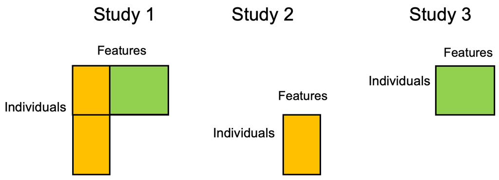

In recent days, datasets with information on all desired features typically have small sample sizes, but one or more external studies with limited set of predictors sometimes have large sample sizes. HTL-GMM method (Heterogeneous Transfer Learning with Generalized Method of Moments) aims to build GLMs and Cox PH models with all desired features incorporating the external studies, which can be potentially high-dimensional.

This tutorial serves as an introduction of HTL-GMM method. We will introduce the R package usage and some application examples. Please refer to https://arxiv.org/abs/2312.12786 for the work of HTL-GMM method.

# **Code for HTL-GMM Manuscript**

Please refer to https://github.com/RuzhangZhao/htlgmm_data_analysis to download the code for simulation and real data application mentioned in the HTL-GMM Manuscript.

# **Installation**

```r
devtools::install_github("RuzhangZhao/htlgmm",force = T)
```

# **Method Recap**

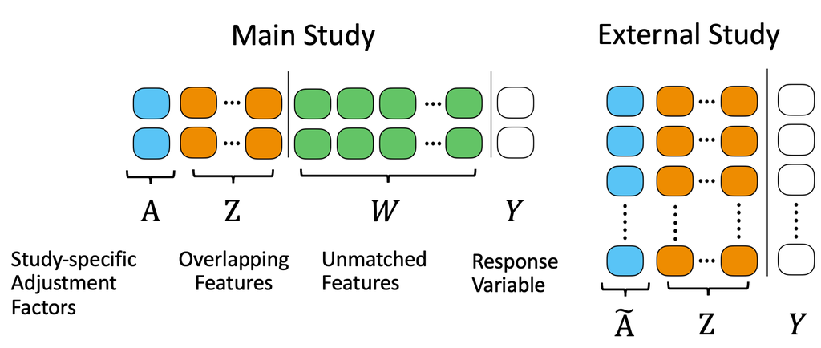

- Main study and external study can be from the same or different population.
- External study can be in the form of individual data or pre-trained model with parameter estimation.
- ${\bf A}$ and $\tilde{\bf A}$: study-specific adjustment factors; ${\bf Z}$: overlapping features in both main and external studies; ${\bf W}$: unmatched features only in main study; ${\bf Y}$: outcome variable (family = “gaussian”: continuous; family = “binomial”: binary)

# **Function Usage of Package htlgmm**

**Primary Functions of Package htlgmm**

We primarily provid three functions **`htlgmm`**, **`cv.htlgmm`**, **`gwas.htlgmm`**. The first two work similarly like functions `glmnet` and `cv.glmnet` from R package `glmnet`. `cv.glmnet`/`cv.htlgmm` does cross validation with automatically generated tuning parameter list(s) to select tuning parameters. We recommend users to use `cv.htlgmm` without knowing prefixed tuning parameters.

**`htlgmm`**

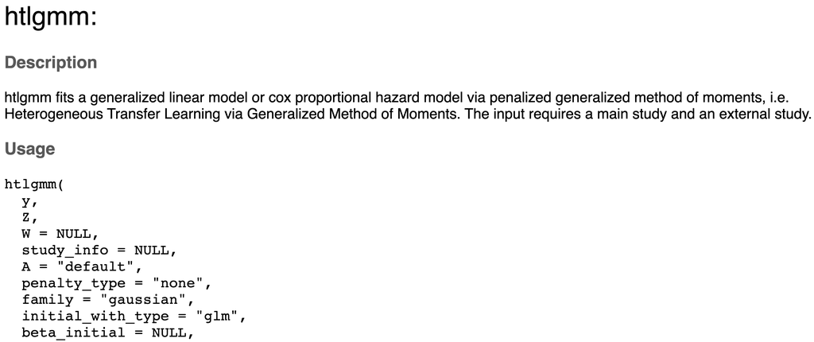

**`cv.htlgmm`**

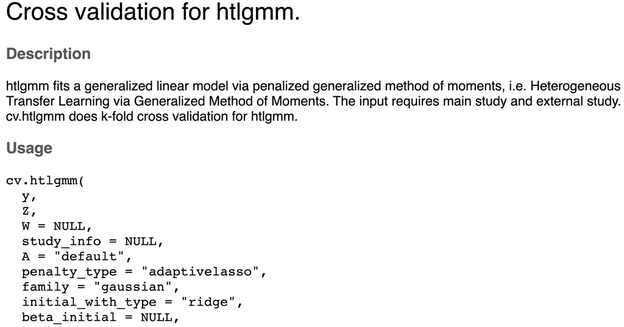

**`gwas.htlgmm`**

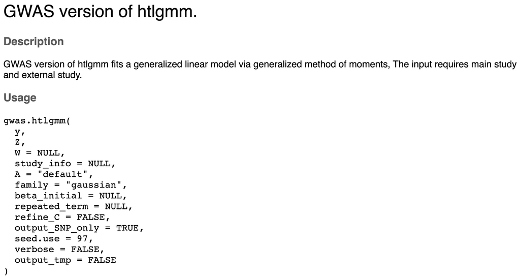

## **Input Parameters of `cv.htlgmm`**

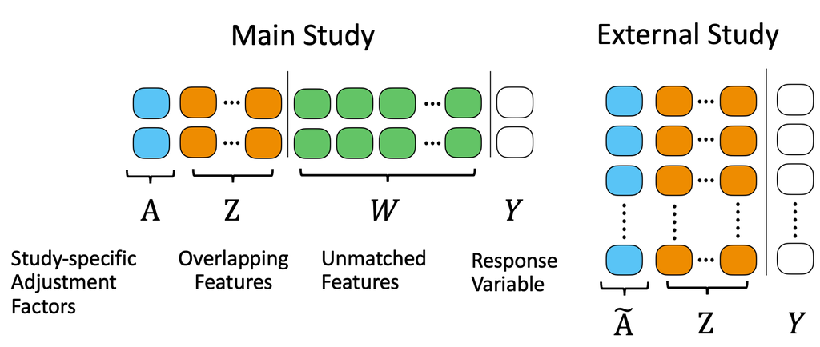

**Click for more details of input parameters**

- **initial_with_type**: Get initial estimation for beta using main study data only by cross validation using penalty regression, chosen from c(“ridge”,“lasso”,“glm”).
- **weight_adaptivelasso**: The customized adaptive-weight of adaptive lasso when using penalty_type = “adaptivelasso”.
- **alpha**: The elasticnet mixing parameter, between 0 and 1, which is corresponding to the alpha for glmnet. Only used when penalty_type = “elasticnet”.
- **hat_thetaA**: If A is not NULL, one can provide hat_thetaA as the input. If “hat_thetaA = NULL”, we estimate hat_thetaA with glm by main study.
- **V_thetaA**: If A is not NULL, one can provide V_thetaA as the input. If “V_thetaA = NULL”, we estimate V_thetaA with glm by main study.
- **remove_penalty_Z**: Do not penalize Z if it is TRUE. The default is FALSE.
- **remove_penalty_W**: Do not penalize W if it is TRUE. The default is FALSE.
- **inference**: Whether to do inference without penalty or post-selection inference with adaptive lasso penalty. The default is “default”, which is TRUE when penalty_type = “none” or “adaptivelasso”, and FALSE otherwise.
- **fix_C**: When fix_C = NULL, the optimal C is computed. When user wants to customize the fix_C, please match its dimension as dim(A)+2*dim(Z)+dim(W) and make sure it is positive definite.
- **fix_inv_C**: When fix_inv_C = NULL, the optimal C is computed. When user wants to customize the fix_inv_C, please match its dimension as dim(A)+2*dim(Z)+dim(W) and make sure it is positive definite. When fix_C and fix_inv_C are both given, the fix_C will be used.
- **type_measure**: Select from c(“default”, “mse”, “deviance”, “auc”). Default is mse(liner), auc(logistic). “deviance” is another choice for binary y.
- **fix_weight**: The fixed weight for the regularization of weighting matrix. The default is NULL. If it is NULL, select the best weight via cross validation.
- **weight_list**: The weight list if it is preset. The default is NULL and weight list will be generated.
- **gamma_adaptivelasso**: The gamma for adaptive lasso. Select from c(1/2,1,2). The default is 1/2.

## **Output Values of `cv.htlgmm`**

- **beta** : Target coefficient estimation of all predictors. The coefficients go with the order of (A, Z, W).
- **lambda_list**: The lambda list for cross validation.
- **weight_list**: The weight list for cross validation, when set tune_weight = TRUE.
- **cv_mse**: The mean square error(mse) when family = “gaussian” for cross validation.
- **cv_auc**: The area under ROC curve(auc) when family = “binomial” for cross validation. For each lambda, cv_auc is the average auc across all folds.
- **cv_dev**: The deviance(dev) when family = “binomial” for cross validation An alternative choice of cv_auc.
- **lambda_min**: The selected best lambda.
- **weight_min**: The selected best weight, when set tune_weight = TRUE.
- **selected_vars**: A list of results for predictors with nonzero estimated coefficients.
  - **position**: the position of nonzero predictors.
  - **name**: the name of nonzero predictors.
  - **coef**: the coefficient of nonzero predictors.
  - **variance**: the variance of nonzero predictors.
  - **variance-covariance**: the variance-covariance matrix of nonzero predictors.
  - **pval**: the p values of nonzero predictors.

# **Simulation Examples with Binary Outcome**

In this simulation example, we illustrate the usage of `cv.htlgmm` for binary outcome.

**Simulation Setup**

The simulation example is to illustrate how the `cv.htlgmm` method is implemented, compared with `cv.glmnet`. The simulation is performed under logistic regression setting. We use **20** overlapping features (**Z**) and **100** unmatched features (**W**). 3/20 of **Z** whose effects on outcome are nonzero, while 2/100 of **W** whose effects on outcome are nonzero.

Main study sample size **n** is 500, while external study sample size **nE** is 3000.

**Click for data generation simulation code**

```r
library(htlgmm)
pZ=20 # overlapping features
pW=100 # unmatched features
coef<-c(rep(0,pZ+pW))
coef[1:3]<-0.5
coef[c(21,22)]<-0.5
n=500
nE=3000
n_joint=n+nE
main_index<-1:n
print(paste0("Nonzero positions: ",paste(which(coef!=0),collapse = ", ")))
```

```
## [1] "Nonzero positions: 1, 2, 3, 21, 22"
```

We jointly generate main and external studies.

**y** is generated with both **Z** and **W**.

```r
set.seed(1)
Z_joint<-matrix(rnorm(n_joint*pZ),n_joint,pZ)
colnames(Z_joint)<-paste0("Z",1:pZ)
W_joint<-matrix(rnorm(n_joint*pW),n_joint,pW)
colnames(W_joint)<-paste0("W",1:pW)
Z<-Z_joint[main_index,]  # separate main and external study for Z
ZE<-Z_joint[-main_index,]

W<-W_joint[main_index,] # only need main study for W

y_joint<-rbinom(n=n_joint,size=1,prob=expit(cbind(Z_joint,W_joint)%*%coef))
y<-y_joint[main_index] # separate main study y
yE<-y_joint[-main_index] # separate external study y
```

Display the data structure of main study **(y, Z, W)** with the first 2 rows and first 30 columns.

```r
main_study<-cbind(y,Z,W)
head(main_study,2)[,1:30]
```

```
##      y         Z1        Z2         Z3         Z4        Z5         Z6
## [1,] 1 -0.6264538 0.5205997 -1.3254177  0.7051107 0.5232667 -2.4675028
## [2,] 0  0.1836433 0.3775619  0.9519797 -0.6268688 0.9935537 -0.7000656
##              Z7         Z8          Z9       Z10        Z11       Z12
## [1,]  0.6010915 -0.9252129  0.97027832 0.5375559  0.6986309 0.5574862
## [2,] -2.7671158  0.1805965 -0.02072336 0.2271813 -1.1650711 0.3520408
##             Z13       Z14         Z15       Z16       Z17        Z18      Z19
## [1,]  0.3707608 2.5285947 -0.06455497 -1.504228 1.2651240  0.7859485 1.380371
## [2,] -0.7265963 0.1232134 -0.58150321  1.093152 0.5123215 -0.4794245 1.682890
##            Z20          W1         W2       W3         W4         W5         W6
## [1,] 0.3768347 -1.00203611 -0.7132184 1.042499  0.9530678  1.1411060  0.3168121
## [2,] 1.2553529  0.02590761 -1.0166592 1.080826 -0.4157007 -0.6290421 -1.2707453
##             W7         W8          W9
## [1,] 0.7156816 -0.9463759  0.52378339
## [2,] 1.4276169 -1.4034296 -0.06035219
```

Display the data structure of external study **(yE, ZE)**.

```r
external_study<-cbind(yE,ZE)
head(external_study,2)
```

```
##      yE          Z1         Z2         Z3        Z4         Z5        Z6
## [1,]  0  0.07730312 -1.1346302 -0.7948034 -1.411522 -0.5676023 0.9514099
## [2,]  1 -0.29686864  0.7645571  0.6060846  1.083870  0.4837350 0.4570987
##              Z7         Z8         Z9        Z10       Z11       Z12        Z13
## [1,] -0.5682999  0.1965621  0.5263087 -1.0905102 0.8084132 -1.680998 -0.4447731
## [2,]  0.1131262 -0.4199427 -1.1767110 -0.4629759 1.5886737  1.265549  0.4094111
##             Z14        Z15        Z16        Z17       Z18       Z19       Z20
## [1,] -1.6220979  0.5468718 -0.6363353 -1.6490749 0.3413341  1.564013 -1.024849
## [2,]  0.1897096 -0.1667157  0.7258137 -0.7714769 0.4136665 -0.795476 -1.249276
```

Scale **Z** and **W** predictors

```r
Z<-scale(Z)
ZE<-scale(ZE)
W<-scale(W)
```

## **Train with External Study by glm**

Summarize external study to be pre-trained model with parameter estimation. Here we use GLM with external study **(yE,ZE)**. Extract estimated coefficients (other than intercept terms, only for **Z**), variance-covariance matrix. Convert the results into a list.

```r
resglm<-glm(y~.,data = data.frame(y=yE,ZE),family = "binomial")
study_external = list(
                Coeff=resglm$coefficients[-1],
                Covariance=vcov(resglm)[-1,-1])
ext_study_info<-list()
ext_study_info[[1]] <- study_external
```

## **Train with Main and External Studies by `cv.htlgmm`**

Train with `cv.htlgmm`, the family is `binomial`. First train HTL-GMM using lasso. The `tune_weight` option introduces the regularization of weighting matrix.

```r
res_htlgmm<-cv.htlgmm(y=y,
                      Z=Z,
                      W=W,
                      ext_study_info = ext_study_info,
                      family="binomial",
                      tune_weight = T,
                      penalty_type = "lasso",
                      beta_initial = as.vector(coef(res_glmnet,s="lambda.min")))
```

For HTL-GMM using adaptive lasso, the adaptive weight is recommended using weight from ridge regression. When using adaptive lasso, the inference outputs are generated by default.

```r
res_ridge<-cv.glmnet(x=cbind(Z,W),y=y,alpha=0,family="binomial")
weight_adaptivelasso<-1/abs(c(coef(res_ridge,s="lambda.min")[-1]))^(1/2)
res_htlgmm_ada<-cv.htlgmm(y=y,
                      Z=Z,
                      W=W,
                      ext_study_info = ext_study_info,
                      family="binomial",
                      tune_weight = T,
                      penalty_type = "adaptivelasso",
                      weight_adaptivelasso = weight_adaptivelasso,
                      beta_initial = as.vector(coef(res_glmnet,s="lambda.min")))
```

Check the estimation error between estimated coefficients and true coefficients.

```
## Estimation Error: lasso(0.2046);
##  htlgmm(0.0734)
```

**Click for comparison code**

```r
est_coef_htlgmm<-res_htlgmm$beta[-1]
ee_htlgmm<-sum((coef-est_coef_htlgmm)^2)
ee_htlgmm<-round(ee_htlgmm,4)

est_coef_lasso<-coef.glmnet(res_glmnet,s="lambda.min")[-1]
ee_lasso<-sum((coef-est_coef_lasso)^2)
ee_lasso<-round(ee_lasso,4)

cat(paste0("Estimation Error: ","lasso(",ee_lasso,");\n htlgmm(",ee_htlgmm,")"))
```

```
## Estimation Error: lasso(0.2046);
##  htlgmm(0.0734)
```

Check the out of sample prediction performance on test data with 2000 sample size.

```
## AUC on test data: lasso(0.7355);
##  htlgmm(0.7467)
```

**Click for test data generation simulation code**

```r
n_test = 2000
set.seed(203)
Z_test<-matrix(rnorm(n_test*pZ),n_test,pZ)
colnames(Z_test)<-paste0("Z",1:pZ)
W_test<-matrix(rnorm(n_test*pW),n_test,pW)
colnames(W_joint)<-paste0("W",1:pW)

y_test<-rbinom(n=n_test,size=1,prob=expit(cbind(Z_test,W_test)%*%coef))
library(pROC)
# intercepts of estimated coefficients are ignored
# since intercepts do not affect AUC.
pred_y_htlgmm<-cbind(Z_test,W_test)%*%est_coef_htlgmm
pred_y_lasso<-cbind(Z_test,W_test)%*%est_coef_lasso

suppressMessages(auc_htlgmm<-c(auc(y_test,c(htlgmm::expit(pred_y_htlgmm)),direction = "<")))
suppressMessages(auc_lasso<-c(auc(y_test,c(htlgmm::expit(pred_y_lasso)),direction = "<")))

cat(paste0("AUC on test data: ","lasso(",round(auc_lasso,4),");\n htlgmm(",round(auc_htlgmm,4),")"))
```

```
## AUC on test data: lasso(0.7355);
##  htlgmm(0.7467)
```

**Click for detailed inference output of `cv.htlgmm`**

Example of **beta**

```r
est_coef_htlgmm<-res_htlgmm$beta
names(est_coef_htlgmm)<-c("Intercept",paste0('Z',1:pZ),paste0('W',1:pW))
est_coef_htlgmm[1:30] # only show the first 30 coefficients
```

```
##    Intercept           Z1           Z2           Z3           Z4           Z5
## -0.044383546  0.498662972  0.448938638  0.308491332  0.000000000  0.000000000
##           Z6           Z7           Z8           Z9          Z10          Z11
##  0.000000000  0.000000000  0.000000000  0.000000000  0.000000000  0.000000000
##          Z12          Z13          Z14          Z15          Z16          Z17
##  0.000000000  0.000000000  0.000000000  0.028778728 -0.008967114 -0.053259808
##          Z18          Z19          Z20           W1           W2           W3
##  0.000000000  0.000000000  0.000000000  0.461327236  0.356570948  0.000000000
##           W4           W5           W6           W7           W8           W9
##  0.000000000  0.000000000  0.000000000  0.000000000  0.000000000  0.000000000
```

HTLGMM selected_vars

```r
print(res_htlgmm_ada$selected_vars$coef)
```

```
## [1] -0.04140164  0.51867246  0.46843552  0.31214784  0.48650693  0.40330147
## [7] -0.03980315 -0.03332190
```

```r
print(res_htlgmm_ada$selected_vars$variance)
```

```
## [1] 0.007575373 0.002137143 0.002087740 0.002199780 0.007014063 0.007770544
## [7] 0.006641592 0.006219383
```

```r
print(res_htlgmm_ada$selected_vars$pval)
```

```
## [1] 6.343018e-01 3.268335e-29 1.158337e-24 2.826334e-11 6.283285e-09
## [6] 4.759089e-06 6.252620e-01 6.726392e-01
```

The FDR adjusted positions passing significant level 0.05 after BH adjustment.

```r
print(paste0("The predictors whose effects on outcome are nonzero: ",paste(c(paste0('Z',1:pZ),paste0('W',1:pW))[coef!=0],collapse = ", ")))
```

```
## [1] "The predictors whose effects on outcome are nonzero: Z1, Z2, Z3, W1, W2"
```

```r
print(paste0("The predictors selected by htlgmm after FDR adjustment :",paste(res_htlgmm_ada$selected_vars$FDR_adjust_name,collapse = ", ")))
```

```
## [1] "The predictors selected by htlgmm after FDR adjustment :Z1, Z2, Z3, W1, W2"
```

The lambda list and cross validation auc.

```r
head(lambda_mse_df<-data.frame(lambda=res_htlgmm$lambda_list,
                  cv_mse=t(res_htlgmm$cv_auc)))
```

```
##      lambda  cv_mse.1  cv_mse.2  cv_mse.3  cv_mse.4  cv_mse.5  cv_mse.6
## 1 0.5551131 0.5000000 0.5000000 0.5000000 0.5000000 0.5000000 0.5000000
## 2 0.5057983 0.7249778 0.7248000 0.7253333 0.7239111 0.7328000 0.7212444
## 3 0.4608646 0.7224889 0.7226667 0.7233778 0.7328000 0.7233778 0.7155556
## 4 0.4199227 0.7232000 0.7226667 0.7248000 0.7285333 0.7182222 0.7107556
## 5 0.3826179 0.7223111 0.7248000 0.7306667 0.7244444 0.7162667 0.7100444
## 6 0.3486272 0.7212444 0.7304889 0.7328000 0.7232000 0.7143111 0.7091556
```

The best selected lambda.

```r
lambda_min<-res_htlgmm$lambda_min
print(lambda_min)
```

```
## [1] 0.0542351
```

# **Real Application Example for Risk Prediction**

**The real application for 10-year risk prediction of “incident” Breast Cancer using proteomics and risk factor data**

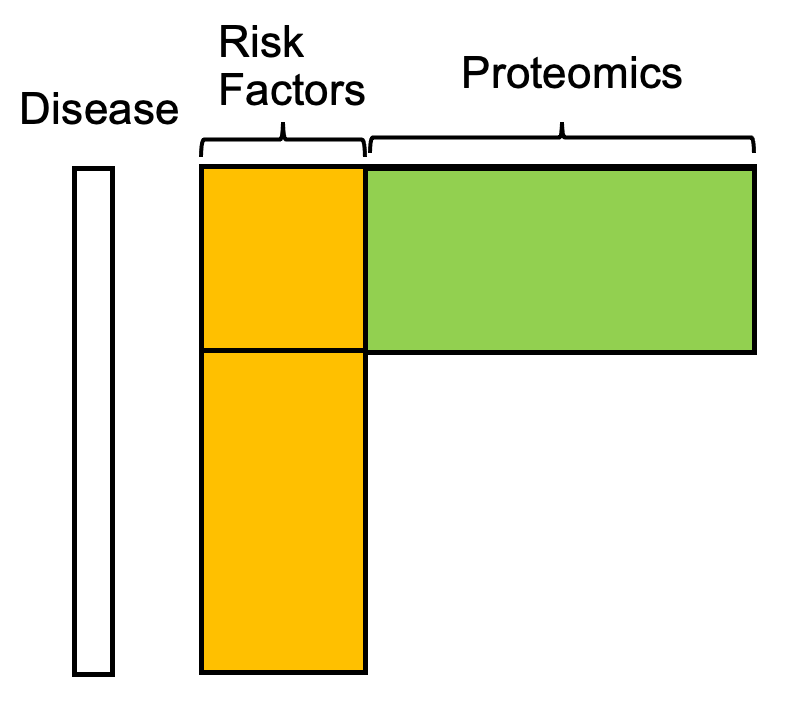

The proteomics data is downloaded from https://www.ukbiobank.ac.uk/enable-your-research/about-our-data/past-data-releases

The risk factors are downloaded from https://biobank.ndph.ox.ac.uk/showcase/browse.cgi

Because of data privacy issue, we use simulated risk factor and proteomics data for the application of `cv.htlgmm` here.

**Click for risk factor and proteomics data generation simulation code**

Load the required package including `htlgmm`.

```r
library(caret)
library(glmnet)
library(htlgmm)
library(pROC)
```

**Simulated UKB data including disease status, risk factor and proteomics**

The risk factors names are listed from the Breast Cancer related ones. Record the summarized mean and standard deviance for each risk factor, including whether the predictors are binary or continuous.

```r
risk_factor_names<-c("age","BMI","Height","Smoking_Status","Alcohol_Freq",
                     "Mother_Breast_Cancer_History","Silbings_Breast_Cancer_History",
                     "Number_of_Birth","Age_Menarche","Ever_Used_Oral_Contraceptive",
                     "Ever_Received_Hormone_Replacement_Therapy",
                     "Ever_Received_Bilateral_Oophorectomy",
                     "Ever_Had_Still_Birth","Prevalent_Benign_Breast_Disease")

mean_risk_factor<-c(59.7636,27.1449,162.1822,0.3442,0.1804,0.0758,0.0409,1.8789,12.9352,0.8001,0.4922,0.0961,0.3094,0.0083)

sd_risk_factor<-c(5.4963,5.0753,6.1417,0.4751,0.3845,0.2647,0.1980,1.1317,1.6063,0.3999,0.4999,0.2948,0.4622,0.0907)

names(mean_risk_factor)<-risk_factor_names
print(mean_risk_factor)
```

```
##                                       age
##                                   59.7636
##                                       BMI
##                                   27.1449
##                                    Height
##                                  162.1822
##                            Smoking_Status
##                                    0.3442
##                              Alcohol_Freq
##                                    0.1804
##              Mother_Breast_Cancer_History
##                                    0.0758
##            Silbings_Breast_Cancer_History
##                                    0.0409
##                           Number_of_Birth
##                                    1.8789
##                              Age_Menarche
##                                   12.9352
##              Ever_Used_Oral_Contraceptive
##                                    0.8001
## Ever_Received_Hormone_Replacement_Therapy
##                                    0.4922
##      Ever_Received_Bilateral_Oophorectomy
##                                    0.0961
##                      Ever_Had_Still_Birth
##                                    0.3094
##           Prevalent_Benign_Breast_Disease
##                                    0.0083
```

For simplicity, we assume all binary risk factors follow binomial distribution and continuous risk factors follow normal distribution. We perform case-control analysis to allow fast computation in this simulation. The main study is assumed to be 2,000, and the external study is 9 times more, where the ratio is similar to actual case.

There are in total 1,500 proteins in UK Biobank proteomics data, we use 500 for simulation.

```r
binary_predictors<-c("Mother_Breast_Cancer_History",
                     "Silbings_Breast_Cancer_History",
                     "Ever_Used_Oral_Contraceptive",
                     "Ever_Received_Hormone_Replacement_Therapy",
                     "Ever_Received_Bilateral_Oophorectomy",
                     "Ever_Had_Still_Birth",
                     "Prevalent_Benign_Breast_Disease")

n_main<-2000
n_external<-n_main*9
n_joint<-n_main+n_external
p_protein<-500
set.seed(2023)
risk_factor<-list()
for( i in which(risk_factor_names%in%binary_predictors)){
    risk_factor[[i]]<-rbinom(n = n_joint,size = 1,prob = mean_risk_factor[i])
}
for( i in which(!risk_factor_names%in%binary_predictors)){
    risk_factor[[i]]<-rnorm(n = n_joint,mean = mean_risk_factor[i],sd = sd_risk_factor[i])
}
risk_factor_matrix<-Reduce("cbind",risk_factor)
```

Check the data structure of the risk factor matrix, which is similar to the actual data structure.

```r
colnames(risk_factor_matrix)<-risk_factor_names
round(head(risk_factor_matrix,2),2)
```

```
##        age   BMI Height Smoking_Status Alcohol_Freq
## [1,] 64.52 31.98 160.26          -0.23         0.61
## [2,] 44.70 27.05 168.29           0.38         0.20
##      Mother_Breast_Cancer_History Silbings_Breast_Cancer_History
## [1,]                            0                              0
## [2,]                            0                              0
##      Number_of_Birth Age_Menarche Ever_Used_Oral_Contraceptive
## [1,]            2.62        14.42                            0
## [2,]            3.12        13.53                            1
##      Ever_Received_Hormone_Replacement_Therapy
## [1,]                                         0
## [2,]                                         1
##      Ever_Received_Bilateral_Oophorectomy Ever_Had_Still_Birth
## [1,]                                    0                    0
## [2,]                                    0                    0
##      Prevalent_Benign_Breast_Disease
## [1,]                               0
## [2,]                               0
```

The proteins are assumed to follow N(0,1).

```r
proteomics_matrix<-matrix(rnorm(n_joint*p_protein),nrow = n_joint,ncol = p_protein)
eg_proteomics<-proteomics_matrix[1:6,1:5]
colnames(eg_proteomics)<-c("aarsd1","abhd14b","abl1","acaa1","ace2")
eg_proteomics
```

```
##          aarsd1     abhd14b       abl1      acaa1          ace2
## [1,] -1.1105242 -0.01414405 -1.0864208 -0.5041349  4.490670e-01
## [2,]  1.0969956  0.81478464 -0.3507938 -1.2923906 -1.026354e-01
## [3,]  0.1096429  1.17141003 -0.6785858  1.6844419 -6.698569e-05
## [4,] -0.4895755  0.09112312 -0.5685032 -0.6172262 -5.422962e-01
## [5,]  1.0021940  0.66385649 -1.4594543  0.6078855 -1.003801e+00
## [6,] -1.0121142 -0.64776973 -0.4683433 -1.1744974 -1.432753e+00
```

We assume the disease status follows binomial distribution, and the case:control ratio to be roughly 0.1.

```r
coef_risk_factor<-c(0.1172,0.1216,0.1067,-0.0312,0.0816,0.1038,0.0755,-0.0507,-0.0099,-0.0099,0.0376,-0.0266,-0.0251,0.0628)
coef_proteomics<-rep(0,p_protein)
set.seed(2024)
coef_proteomics[sample(1:p_protein,20)]<-rnorm(20,mean=0,sd = 0.1)

mean_case<-0.1
Y<-rbinom(n_joint,size = 1,prob =expit(
    log(mean_case/(1-mean_case))+c(scale(risk_factor_matrix)%*%coef_risk_factor)+c(proteomics_matrix%*%coef_proteomics)))
print(paste0("simulated disease prevalence:",sum(Y)/n_joint))
```

```
## [1] "simulated disease prevalence:0.11255"
```

Separate the simulated data into main study and external study.

```r
main_study<-data.frame(Y = Y[1:n_main],risk_factor_matrix[1:n_main,],proteomics_matrix[1:n_main,])

external_study<-data.frame(Y = Y[-c(1:n_main)],risk_factor_matrix[-c(1:n_main),])
```

Scale the predictors from external study. Extract summary statistics from external study.

```r
external_study[,-1]=scale(external_study[,-1])
family = "binomial"
ext_study_info=list()
external_glm=glm(Y~.,data = external_study,family = family)
study_external = list(
                Coeff=external_glm$coefficients[-1],
                Covariance=vcov(external_glm)[-1,-1])
ext_study_info[[1]] = study_external
#ext_study_info
```

Split main study into train and test with the proportion (70% and 30%).

```r
library(caret)
set.seed(2024)
test_index=createDataPartition(main_study$Y,p = 0.3)$Resample1
```

```r
y = main_study$Y[-test_index]
X = as.matrix(main_study[-test_index,-1])
y_test = main_study$Y[test_index]
X_test = as.matrix(main_study[test_index,-1])
prefunc <- preProcess(X, method = c("center", "scale"))
X = predict(prefunc, X)
X_test = as.matrix(predict(prefunc, X_test))
p_risk = ncol(external_study)-1
```

## **Train with Main Study by cv.glmnet**

y and X are training sets for main study, while y_test and X_test are test sets for main study. We perform normalization on X and apply the same transformation to X_test.

Perform `cv.glmnet` only for main study’s training set and check the performance on main study’s test set. The criterion is AUC.

```r
start_t=Sys.time()
main_lasso=cv.glmnet(x=X, y=y, family="binomial")
end_t=Sys.time()
sprintf('cv.glmnet time: %.2f %s', end_t-start_t, units(end_t-start_t))
```

```
## [1] "cv.glmnet time: 14.27 secs"
```

```r
pred_main_lasso=c(predict(main_lasso,newx=X_test,s="lambda.min"))
suppressMessages(auc_main_lasso<-auc(y_test,expit(pred_main_lasso)))
```

## **Train with Main study and External Study by `cv.htlgmm`**

Perform `cv.htlgmm` for main study’s training set with external study and check the performance on main study’s test set. The initial beta for `cv.htlgmm` is taken from the output of `cv.glmnet`.

```r
start_t=Sys.time()
main_external_htlgmm=htlgmm::cv.htlgmm(y = y,
                               Z = X[,c(1:p_risk)],
                               W = X[,-c(1:p_risk)],
                               ext_study_info = ext_study_info,
                               penalty_type = "lasso",
                               beta_initial = as.vector(coef(main_lasso,s="lambda.min")),
                               family = "binomial")
end_t=Sys.time()
sprintf('cv.htlgmm time: %.2f %s', end_t-start_t, units(end_t-start_t))
```

```
## [1] "cv.htlgmm time: 18.03 secs"
```

Perform `cv.htlgmm` with the option of weight tuning by setting tune_weight = TRUE.

```r
start_t=Sys.time()
main_external_htlgmm_tune=htlgmm::cv.htlgmm(y = y,
                               Z = X[,c(1:p_risk)],
                               W = X[,-c(1:p_risk)],
                               ext_study_info = ext_study_info,
                               family = "binomial",
                               penalty_type = "lasso",
                               beta_initial = as.vector(coef(main_lasso,s="lambda.min")),
                               tune_weight = TRUE)
end_t=Sys.time()
sprintf('cv.htlgmm with weight tuning time: %.2f %s', end_t-start_t, units(end_t-start_t))
```

```
## [1] "cv.htlgmm with weight tuning time: 35.51 secs"
```

## **Performance Comparison**

Check the AUC comparison between `cv.glmnet` and `cv.htlgmm`.

```
## AUC on test data: main study only lasso(0.544);
##  htlgmm(0.5477);
##  htlgmm_tune_weight(0.5921)
```

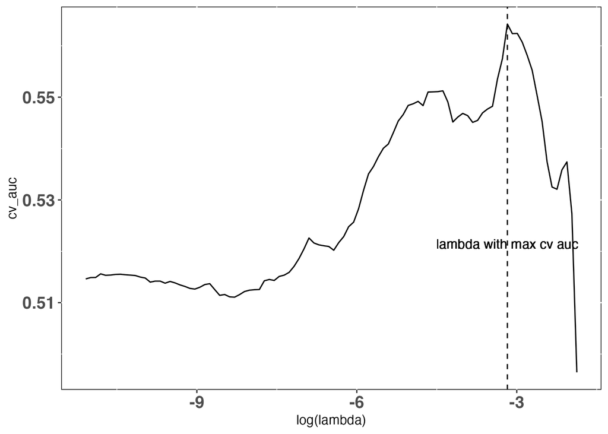

**Click for comparison code**

```r
pred_main_external_htlgmm=c(X_test%*%main_external_htlgmm$beta[-1])
suppressMessages(auc_main_external_htlgmm<-pROC::auc(y_test,expit(pred_main_external_htlgmm)))

pred_main_external_htlgmm_tune=c(X_test%*%main_external_htlgmm_tune$beta[-1])
suppressMessages(auc_main_external_htlgmm_tune<-pROC::auc(y_test,expit(pred_main_external_htlgmm_tune)))

cat(paste0("AUC on test data: main study only lasso(",round(auc_main_lasso,4) ,");\n htlgmm(", round(auc_main_external_htlgmm,4),");\n htlgmm_tune_weight(",round(auc_main_external_htlgmm_tune,4),")"))
```

```
## AUC on test data: main study only lasso(0.544);
##  htlgmm(0.5477);
##  htlgmm_tune_weight(0.5921)
```

[figure not shown]

```r
df = data.frame(lambda = main_external_htlgmm$lambda_list,
                cv_dev=main_external_htlgmm$cv_dev,
                cv_auc=main_external_htlgmm$cv_auc)
library(ggplot2)
ggplot(df)+
  geom_line(aes(x=log(lambda),y=cv_auc))+
  geom_vline(xintercept = log(main_external_htlgmm$lambda_min),
             linetype=2)+
  theme(panel.background=element_rect(fill='transparent', color='black'),
        axis.text=element_text(size=14,face="bold"))+
  geom_text(aes(x=log(main_external_htlgmm$lambda_min),y=median(cv_auc),label='lambda with max cv auc'))
```

# **GWAS version of HTLGMM**

In this example, simulation example is generated to illustrate the application of **`gwas.htlgmm`**.

We simulate SNP_matrix by binomial distribution, where the allele frequencies are simulated from uniform distribution. We consider 100 SNPs, with main study sample size 10k and external summary statistics with sample size 100k.

The adjustment covariates include age, sex, BMI. Assume age and sex are adjusted from external summary statistics, while BMI is not adjusted. We can further adjust BMI using both main study and external summary statistics by `gwas.htlgmm`.

## **Simulation Setup**

**Click for genotype and phenotype generation simulation code, including how to set up main and external studies**

**Simulate SNP matrix and covariates**

```r
library(htlgmm)
snp_count<-100
n_ext<-1e5
n_main<-1e4
n_joint<-n_main+n_ext
set.seed(2024)
allele_freq<-runif(snp_count,min = 0.1,max = 0.9)
snp_matrix<-sapply(1:snp_count, function(i){
    rbinom(n=n_joint,size=2,prob=allele_freq[i])})

age<-rnorm(n_joint,mean = 60,sd = 5)
sex<-rbinom(n_joint,size=1,prob = 0.5)
BMI<-rnorm(n_joint,mean = 27,sd = 5)
```

**Simulate binary outcome by randomly setting casual SNPs**

Randomly set true casual SNP postions and check the case and control counts for simulated disease.

```r
true_snp_position<-sample(1:100,5)
coef_snp<-rep(0,snp_count)
coef_snp[true_snp_position]<-log(1.2)*sample(c(1,-1),5,replace=TRUE)
print(paste0("True Causal SNP Positions: ",paste(sort(true_snp_position),collapse = ", ")))
```

```
## [1] "True Causal SNP Positions: 7, 10, 19, 27, 98"
```

```r
coef_risk_factor<-c(0.1172,-0.05,0.1216)
risk_factor_matrix<-cbind(age,sex,BMI)

t2d<-rbinom(n_joint,size = 1,prob = expit(
    log(0.1/(1-0.1))+c(scale(risk_factor_matrix)%*%coef_risk_factor)+c(snp_matrix%*%coef_snp)))
table(t2d)
```

```
## t2d
##     0     1
## 98858 11142
```

**Split simulated data into main study and external study**

**A** consist of age and sex; **W** only includes BMI; **Z** only includes each SNP. In general case, **A**, and **W** can be lists of covariates. For the **A** input of `gwas.htlgmm`, a column of **1** is required for intercept term.

```r
A<-cbind(1,risk_factor_matrix[1:n_main,c(1,2)])
AE<-cbind(1,risk_factor_matrix[-c(1:n_main),c(1,2)])
W<-risk_factor_matrix[1:n_main,3,drop=F]
y<-t2d[1:n_main]
yE<-t2d[-c(1:n_main)]
snp_matrix_main<-snp_matrix[1:n_main,]
snp_matrix_ext<-snp_matrix[-c(1:n_main),]
```

**Simulate External GWAS Summary Statistics**

The simulated external summary statistics **ext_study_info** is corresponding to the external summary statistics we usually obtain from a large consortia.

Please follow the list format below for external summary statistics.

```r
ext_study_info<-list()
for(i in 1:snp_count){
    ZE<-snp_matrix_ext[,i]
    resglm<-glm(y~.,data = data.frame(y=yE,ZE,AE[,-1]),family = "binomial")
    study_external = list(
        Coeff=resglm$coefficients[2],
        Covariance=vcov(resglm)[2,2])
    ext_study_info[[i]] <- study_external
}
print(ext_study_info[[1]])
```

```
## $Coeff
##           ZE
## -0.008973933
##
## $Covariance
## [1] 0.0003068138
```

```r
# center A and W except intercept term
A[,-1]<-scale(A[,-1],scale=F)
W<-scale(W,scale=F)
```

[output not shown]

[output not shown]

## **Input Parameters of `gwas.htlgmm`**

`gwas.htlgmm` requireds:

- **(1)** : All the covariates (**A** & **W**) except intercept term should be centered with mean **0**;
- **(2)** : The SNP variable also needs to be centered with mean **0**;
- **(3)** : With provided beta_initial, the beta_initial should be corresponding to be the centered version and follow the order of (**A**, **W**, **Z**).

## **Train with Main Study and External GWAS by `gwas.htlgmm`**

**Key Parameter List of Function `gwas.htlgmm`**

Note that `repeated_term` should be computed in advance to accelerate the computation.

```r
start_t=Sys.time()
library(speedglm,quietly = T)
# first compute the repeated terms.
repeated_term <- gwas.htlgmm.repeated.term(y,A,"binomial")
beta_list<-c()
se_list<-c()
for(i in 1:snp_count){
    # center SNP
    Z<-snp_matrix_main[,i]
    Z<-scale(Z,scale=F)
    # beta initial
    resglm<-speedglm(y~.,data = data.frame(y=y,A[,-1],W,Z),family=binomial())
    beta_initial<-resglm$coefficients
    # find external gwas
    GWAS_ext_study_info = list()
    GWAS_ext_study_info[[1]] = ext_study_info[[i]]
    res.gwas<-gwas.htlgmm(y,Z,W,GWAS_ext_study_info,A,"binomial",beta_initial,repeated_term=repeated_term)
    beta_list<-c(beta_list,res.gwas$beta)
    se_list<-c(se_list,sqrt(res.gwas$variance))
}
end_t=Sys.time()
sprintf('gwas.htlgmm time: %.2f %s', end_t-start_t, units(end_t-start_t))
```

```
## [1] "gwas.htlgmm time: 3.35 secs"
```

## **Verify the results**

In our simulation, because BMI works as a general strong risk factor, without BMI, the GWAS summary statistics will not result in correct conclusion.

```
## [1] "External GWAS identifies siginicant SNP number of : 93"
```

```
## [1] "gwas.htlgmm identifies siginificant SNP positions: 7, 10, 19, 27, 98"
```

**Click for comparison code**

```r
pval_list_ext<-sapply(1:snp_count, function(i){
  pchisq(ext_study_info[[i]][[1]]^2/ext_study_info[[i]][[2]]^2,1,lower.tail = F)
})
pval_list_htlgmm<-pchisq(beta_list^2/se_list^2,1,lower.tail = F)
print(paste0("External GWAS identifies siginicant SNP number of : ",sum(pval_list_ext<0.05/100)))
```

```
## [1] "External GWAS identifies siginicant SNP number of : 93"
```

```r
print(paste0("gwas.htlgmm identifies siginificant SNP positions: ",paste(which(pval_list_htlgmm<0.05/100),collapse = ", ")))
```

```
## [1] "gwas.htlgmm identifies siginificant SNP positions: 7, 10, 19, 27, 98"
```

## **Accelerate `gwas.htlgmm` by plink2**

**Tutorial of plink2 with example files**

Check this link for introduction of plink2: http://ruzhangzhao.github.io/tutorial/plink2

To be updated.

# **Fast Matrix Production & Inverse**

In our package `htlgmm`, we provide fast implementation of matrix product. Please use `crossprod_fast` to replace `crossprod`, and use `prod_fast` to replace `%*%`. For a matrix `A`, a matrix `B`, a vector `b`.

- **crossprod_fast(A)** : generates $A^\top\cdot A$, previously coded as crossprod($A$) or t($A$)%*%$A$.
- **crossprod_fast(A,B)** : generates $A^\top\cdot B$, previously coded as crossprod($A$,$B$) or t($A$)%*%$B$.
- **crossprod_fast(A,b)** : generates $A^\top\cdot b$, previously coded as crossprod($A$,$b$) or t($A$)%*%$b$.
- **prod_fast(A,B)** : generates $A\cdot B$, previously coded as $A$%*%$B$.
- **prod_fast(A,b)** : generates $A\cdot b$, previously coded as $A$%*%$b$.

Under the same setting $A\cdot B$ for matrix dot product, `%*%` takes time:

```
##    user  system elapsed
##   0.585   0.007   0.593
```

Our fast implementation `prod_fast` takes time:

```
##    user  system elapsed
##   0.163   0.003   0.166
```

Under the same setting $A^\top\cdot B$ for matrix dot product, `crossprod` takes time:

```
##    user  system elapsed
##   0.980   0.008   0.988
```

Our fast implementation `crossprod_fast` takes time:

```
##    user  system elapsed
##   0.161   0.002   0.164
```

**Click for comparison code**

```r
set.seed(1)
x<-matrix(rnorm(1e5),1e2,1e3)
y<-matrix(rnorm(1e5),1e3,1e2)
standard_f<-function(){.<-sapply(1:100, function(i){.<-x%*%y })}
## The standard matrix dot product takes time:
system.time(standard_f())
```

```
##    user  system elapsed
##   0.605   0.009   0.615
```

```r
fast_f<-function(){.<-sapply(1:100, function(i){.<-prod_fast(x,y)})}
## The new fast matrix dot product takes time:
system.time(fast_f())
```

```
##    user  system elapsed
##   0.161   0.003   0.165
```

```r
set.seed(1)
x<-matrix(rnorm(1e5),1e3,1e2)
y<-matrix(rnorm(1e5),1e3,1e2)
standard_f<-function(){
    .<-sapply(1:100, function(i){.<-crossprod(x,y) })
}
## The standard matrix dot product takes time:
system.time(standard_f())
```

```
##    user  system elapsed
##   0.973   0.012   1.002
```

```r
fast_f<-function(){
    .<-sapply(1:100, function(i){.<-crossprod_fast(x,y)})
}
## The new fast matrix dot product takes time:
system.time(fast_f())
```

```
##    user  system elapsed
##   0.164   0.003   0.167
```

In package `htlgmm`, we also provide fast implementation of matrix inverse for positive definite matrix. We compare the computation speed among the following methods:

- **solve** : the default matrix inverse from package base.
- **spdinv** : the inverse of a symmetric positive definite matrix from package Rfast.
- **chol2inv** : the inverse from Choleski (or QR) decomposition from package base.
- **choinv** : the inverse based on Cholesky decomposition from package htlgmm.
- **sqrtchoinv** : for positive definite matrix $A$, $L$ = sqrtchoinv($A$), we have $L^\top\cdot L$ is the inverse of $A$.

Under the same setting for positive definition matrix inverse, `solve` takes time:

```
##    user  system elapsed
##   5.543   0.028   5.577
```

The matrix inverse by ‘spdinv’ takes time:

```
##    user  system elapsed
##   2.978   0.008   2.994
```

The matrix inverse by ‘chol2inv’ takes time:

```
##    user  system elapsed
##   1.583   0.003   1.589
```

Our fast matrix inverse takes time:

```
##    user  system elapsed
##   1.353   0.014   1.370
```

Our fast matrix inverse and square root takes time:

```
##    user  system elapsed
##   0.775   0.016   0.808
```

**Click for comparison code**

```r
set.seed(1)
x<-matrix(rnorm(2e7),1e4,2e3)
xtx<-crossprod_fast(x)
## The matrix inverse by 'solve' takes time:
system.time(.<-base::solve(xtx))
```

```
##    user  system elapsed
##   5.521   0.017   5.545
```

```r
## The matrix inverse by 'spdinv' takes time:
system.time(.<-Rfast::spdinv(xtx))
```

```
##    user  system elapsed
##   2.904   0.006   2.915
```

```r
## The matrix inverse by 'chol2inv' takes time:
system.time(.<- base::chol2inv(xtx))
```

```
##    user  system elapsed
##   1.572   0.003   1.576
```

```r
## The new fast matrix inverse takes time:
system.time(.<-htlgmm::choinv(xtx))
```

```
##    user  system elapsed
##   1.331   0.010   1.342
```

```r
## The new fast matrix inverse and square root takes time:
system.time(.<-htlgmm::sqrtchoinv(xtx))
```

```
##    user  system elapsed
##   0.771   0.007   0.779
```

# **Feedback & Reference**

https://github.com/RuzhangZhao/htlgmm/issues

Please submit any feedback and bugs on github issue page or email Ruzhang Zhao (ruzhangzhao@gmail.com) & Nilanjan Chatterjee (nchatte2@jhu.edu).

Please consider citing our work: [Zhao, Ruzhang, et al. “Heterogeneous Transfer Learning for Building High-Dimensional Generalized Linear Models with Disparate Datasets.” arXiv preprint arXiv:2312.12786 (2023).](https://scholar.google.com/scholar?hl=en&as_sdt=0%2C21&q=Heterogeneous+Transfer+Learning+for+Building+High-Dimensional+Generalized+Linear+Models+with+Disparate+Datasets&btnG=)